# Visualizacion del DataSet

En este notebook se muestran algunos de los mecanismos mas utilizados para la visualizacion de Datos.

## DataSet (Conjunto de datos)

### Descripcion

NSL-KDD is a data set suggested to solve some of the inherent problems of the KDD'99 data set which are mentioned in. Although, this new version of the KDD data set still suffers from some of the problems discussed by McHugh and may not be a perfect representative of existing real networks, because of the lack of public data sets for network-based IDSs, we believe it still can be applied as an effective benchmark data set to help researchers compare different intrusion detection methods. Furthermore, the number of records in the NSL-KDD train and test sets are reasonable. This advantage makes it affordable to run the experiments on the complete set without the need to randomly select a small portion. Consequently, evaluation results of different research work will be consistent and comparable.

### Fichero de datos

- **"KDDTrain+.ARFF:"** The full NSL-KDD train set with binary labels in ARFF format
- **"KDDTrain+.TXT:"** The full NSL-KDD train set including attack-type labels and difficulty level in CSV format

KDDTrain+_20Percent.ARFF: A 20% subset of the KDDTrain+.arff file KDDTrain+_20Percent.TXT: A 20% subset of the KDDTrain+.txt file KDDTest+.ARFF: The full NSL-KDD test set with binary labels in ARFF format KDDTest+.TXT: The full NSL-KDD test set including attack-type labels and difficulty level in CSV format KDDTest-21.ARFF: A subset of the KDDTest+.arff file which does not include records with difficulty level of 21 out of 21 KDDTest-21.TXT: A subset of the KDDTest+.txt file which does not include records with difficulty level of 21 out of 21

An ARFF (Attribute-Relation File Format) file is an ASCII text file that describes a list of instances sharing a set of attributes. ARFF files were developed by the Machine Learning Project at the Department of Computer Science of The University of Waikato for use with the Weka machine learning software. Más información: https://www.cs.waikato.ac.nz/ml/weka/arff.html

```python
# Lecturas del data set mediante funciones de pyhton
with open("datasets/NSL-KDD/KDDTrain+.txt") as train_set:
    df = train_set.readlines()
df
```

[output not shown]

[output cut: 975 more lines]

```python
import pandas as pd
df = pd.read_csv("datasets/NSL-KDD/KDDTrain+.txt")
df
```

|  | 0 | tcp | ftp_data | SF | 491 | 0.1 | 0.2 | 0.3 | 0.4 | 0.5 | ... | 0.17 | 0.03 | 0.17.1 | 0.00.6 | 0.00.7 | 0.00.8 | 0.05 | 0.00.9 | normal | 20 |
| --- | --- | --- | --- | --- | --- | --- | --- | --- | --- | --- | --- | --- | --- | --- | --- | --- | --- | --- | --- | --- | --- |
| 0 | 0 | udp | other | SF | 146 | 0 | 0 | 0 | 0 | 0 | ... | 0.00 | 0.60 | 0.88 | 0.00 | 0.00 | 0.00 | 0.00 | 0.00 | normal | 15 |
| 1 | 0 | tcp | private | S0 | 0 | 0 | 0 | 0 | 0 | 0 | ... | 0.10 | 0.05 | 0.00 | 0.00 | 1.00 | 1.00 | 0.00 | 0.00 | neptune | 19 |
| 2 | 0 | tcp | http | SF | 232 | 8153 | 0 | 0 | 0 | 0 | ... | 1.00 | 0.00 | 0.03 | 0.04 | 0.03 | 0.01 | 0.00 | 0.01 | normal | 21 |
| 3 | 0 | tcp | http | SF | 199 | 420 | 0 | 0 | 0 | 0 | ... | 1.00 | 0.00 | 0.00 | 0.00 | 0.00 | 0.00 | 0.00 | 0.00 | normal | 21 |
| 4 | 0 | tcp | private | REJ | 0 | 0 | 0 | 0 | 0 | 0 | ... | 0.07 | 0.07 | 0.00 | 0.00 | 0.00 | 0.00 | 1.00 | 1.00 | neptune | 21 |
| ... | ... | ... | ... | ... | ... | ... | ... | ... | ... | ... | ... | ... | ... | ... | ... | ... | ... | ... | ... | ... | ... |
| 125967 | 0 | tcp | private | S0 | 0 | 0 | 0 | 0 | 0 | 0 | ... | 0.10 | 0.06 | 0.00 | 0.00 | 1.00 | 1.00 | 0.00 | 0.00 | neptune | 20 |
| 125968 | 8 | udp | private | SF | 105 | 145 | 0 | 0 | 0 | 0 | ... | 0.96 | 0.01 | 0.01 | 0.00 | 0.00 | 0.00 | 0.00 | 0.00 | normal | 21 |
| 125969 | 0 | tcp | smtp | SF | 2231 | 384 | 0 | 0 | 0 | 0 | ... | 0.12 | 0.06 | 0.00 | 0.00 | 0.72 | 0.00 | 0.01 | 0.00 | normal | 18 |
| 125970 | 0 | tcp | klogin | S0 | 0 | 0 | 0 | 0 | 0 | 0 | ... | 0.03 | 0.05 | 0.00 | 0.00 | 1.00 | 1.00 | 0.00 | 0.00 | neptune | 20 |
| 125971 | 0 | tcp | ftp_data | SF | 151 | 0 | 0 | 0 | 0 | 0 | ... | 0.30 | 0.03 | 0.30 | 0.00 | 0.00 | 0.00 | 0.00 | 0.00 | normal | 21 |

125972 rows × 43 columns

# Muestra los ficheros en el directorio del dataset

```python
import os
os.listdir("datasets/NSL-KDD")
```

```
['KDDTest+.arff',
 'index.html',
 'KDDTest1.jpg',
 'KDDTrain+_20Percent.txt',
 'KDDTrain+.arff~',
 'KDDTrain+.txt',
 'KDDTrain+_20Percent.arff',
 'KDDTest-21.txt',
 'KDDTest+.txt',
 'KDDTest-21.arff',
 'KDDTrain1.jpg',
 'KDDTrain+.arff']
```

```python
# Instalamos un nuevo paquete en el kernel de a cual para parsear ficheros ARFF
import sys

!{sys.executable} -m pip install liac-arff
```

```python
import arff

with open("datasets/NSL-KDD/KDDTrain+.arff", 'r') as train_set:
    df = arff.load(train_set)

df.keys()
```

```
dict_keys(['description', 'relation', 'attributes', 'data'])
```

```python
df["data"]
```

[output not shown]

[output cut: 41946 more lines]

[output not shown]

```python
df["attributes"]
```

```
[('duration', 'REAL'),
 ('protocol_type', ['tcp', 'udp', 'icmp']),
 ('service',
  ['aol',
   'auth',
   'bgp',
   'courier',
   'csnet_ns',
   'ctf',
   'daytime',
   'discard',
   'domain',
   'domain_u',
   'echo',
   'eco_i',
   'ecr_i',
   'efs',
   'exec',
   'finger',
   'ftp',
   'ftp_data',
   'gopher',
   'harvest',
   'hostnames',
   'http',
   'http_2784',
   'http_443',
   'http_8001',
   'imap4',
   'IRC',
   'iso_tsap',
   'klogin',
   'kshell',
   'ldap',
   'link',
   'login',
   'mtp',
   'name',
   'netbios_dgm',
   'netbios_ns',
```

[output cut: 68 more lines]

```
 ('srv_rerror_rate', 'REAL'),
 ('same_srv_rate', 'REAL'),
 ('diff_srv_rate', 'REAL'),
 ('srv_diff_host_rate', 'REAL'),
 ('dst_host_count', 'REAL'),
 ('dst_host_srv_count', 'REAL'),
 ('dst_host_same_srv_rate', 'REAL'),
 ('dst_host_diff_srv_rate', 'REAL'),
 ('dst_host_same_src_port_rate', 'REAL'),
 ('dst_host_srv_diff_host_rate', 'REAL'),
 ('dst_host_serror_rate', 'REAL'),
 ('dst_host_srv_serror_rate', 'REAL'),
 ('dst_host_rerror_rate', 'REAL'),
 ('dst_host_srv_rerror_rate', 'REAL'),
 ('class', ['normal', 'anomaly'])]
```

```python
## Parsear los atributos y obtener unicamente los nombres
atributos = [attr[0] for attr in df["attributes"]]
```

```python
## Leer el DataSet con Pandas y facilitar su manipulación
df = pd.DataFrame(df["data"], columns = atributos)
df
```

|  | duration | protocol_type | service | flag | src_bytes | dst_bytes | land | wrong_fragment | urgent | hot | ... | dst_host_srv_count | dst_host_same_srv_rate | dst_host_diff_srv_rate | dst_host_same_src_port_rate | dst_host_srv_diff_host_rate | dst_host_serror_rate | dst_host_srv_serror_rate | dst_host_rerror_rate | dst_host_srv_rerror_rate | class |
| --- | --- | --- | --- | --- | --- | --- | --- | --- | --- | --- | --- | --- | --- | --- | --- | --- | --- | --- | --- | --- | --- |
| 0 | 0.0 | tcp | ftp_data | SF | 491.0 | 0.0 | 0 | 0.0 | 0.0 | 0.0 | ... | 25.0 | 0.17 | 0.03 | 0.17 | 0.00 | 0.00 | 0.00 | 0.05 | 0.00 | normal |
| 1 | 0.0 | udp | other | SF | 146.0 | 0.0 | 0 | 0.0 | 0.0 | 0.0 | ... | 1.0 | 0.00 | 0.60 | 0.88 | 0.00 | 0.00 | 0.00 | 0.00 | 0.00 | normal |
| 2 | 0.0 | tcp | private | S0 | 0.0 | 0.0 | 0 | 0.0 | 0.0 | 0.0 | ... | 26.0 | 0.10 | 0.05 | 0.00 | 0.00 | 1.00 | 1.00 | 0.00 | 0.00 | anomaly |
| 3 | 0.0 | tcp | http | SF | 232.0 | 8153.0 | 0 | 0.0 | 0.0 | 0.0 | ... | 255.0 | 1.00 | 0.00 | 0.03 | 0.04 | 0.03 | 0.01 | 0.00 | 0.01 | normal |
| 4 | 0.0 | tcp | http | SF | 199.0 | 420.0 | 0 | 0.0 | 0.0 | 0.0 | ... | 255.0 | 1.00 | 0.00 | 0.00 | 0.00 | 0.00 | 0.00 | 0.00 | 0.00 | normal |
| ... | ... | ... | ... | ... | ... | ... | ... | ... | ... | ... | ... | ... | ... | ... | ... | ... | ... | ... | ... | ... | ... |
| 125968 | 0.0 | tcp | private | S0 | 0.0 | 0.0 | 0 | 0.0 | 0.0 | 0.0 | ... | 25.0 | 0.10 | 0.06 | 0.00 | 0.00 | 1.00 | 1.00 | 0.00 | 0.00 | anomaly |
| 125969 | 8.0 | udp | private | SF | 105.0 | 145.0 | 0 | 0.0 | 0.0 | 0.0 | ... | 244.0 | 0.96 | 0.01 | 0.01 | 0.00 | 0.00 | 0.00 | 0.00 | 0.00 | normal |
| 125970 | 0.0 | tcp | smtp | SF | 2231.0 | 384.0 | 0 | 0.0 | 0.0 | 0.0 | ... | 30.0 | 0.12 | 0.06 | 0.00 | 0.00 | 0.72 | 0.00 | 0.01 | 0.00 | normal |
| 125971 | 0.0 | tcp | klogin | S0 | 0.0 | 0.0 | 0 | 0.0 | 0.0 | 0.0 | ... | 8.0 | 0.03 | 0.05 | 0.00 | 0.00 | 1.00 | 1.00 | 0.00 | 0.00 | anomaly |
| 125972 | 0.0 | tcp | ftp_data | SF | 151.0 | 0.0 | 0 | 0.0 | 0.0 | 0.0 | ... | 77.0 | 0.30 | 0.03 | 0.30 | 0.00 | 0.00 | 0.00 | 0.00 | 0.00 | normal |

125973 rows × 42 columns

Llegados a este punto, lo ideal es construir una funcion que permita leer el el DataSet de manera mas limpia. Este tipo de practicas son de gran utilidad para que nuestro código en Jupyter Notebook sea más modular y pueda reutilizarse de manera mas sencilla para futuros ejercicios.

```python
def load_kdd_dataset(data_path):
    """Lectura del DataSet NSL-KDD."""
    with open(data_path, 'r') as train_set:
        dataset = arff.load(train_set)
    attributes = [attr[0] for attr in dataset["attributes"]]
    return pd.DataFrame(dataset["data"], columns = attributes)
```

```python
load_kdd_dataset('datasets/NSL-KDD/KDDTrain+.arff')
```

|  | duration | protocol_type | service | flag | src_bytes | dst_bytes | land | wrong_fragment | urgent | hot | ... | dst_host_srv_count | dst_host_same_srv_rate | dst_host_diff_srv_rate | dst_host_same_src_port_rate | dst_host_srv_diff_host_rate | dst_host_serror_rate | dst_host_srv_serror_rate | dst_host_rerror_rate | dst_host_srv_rerror_rate | class |
| --- | --- | --- | --- | --- | --- | --- | --- | --- | --- | --- | --- | --- | --- | --- | --- | --- | --- | --- | --- | --- | --- |
| 0 | 0.0 | tcp | ftp_data | SF | 491.0 | 0.0 | 0 | 0.0 | 0.0 | 0.0 | ... | 25.0 | 0.17 | 0.03 | 0.17 | 0.00 | 0.00 | 0.00 | 0.05 | 0.00 | normal |
| 1 | 0.0 | udp | other | SF | 146.0 | 0.0 | 0 | 0.0 | 0.0 | 0.0 | ... | 1.0 | 0.00 | 0.60 | 0.88 | 0.00 | 0.00 | 0.00 | 0.00 | 0.00 | normal |
| 2 | 0.0 | tcp | private | S0 | 0.0 | 0.0 | 0 | 0.0 | 0.0 | 0.0 | ... | 26.0 | 0.10 | 0.05 | 0.00 | 0.00 | 1.00 | 1.00 | 0.00 | 0.00 | anomaly |
| 3 | 0.0 | tcp | http | SF | 232.0 | 8153.0 | 0 | 0.0 | 0.0 | 0.0 | ... | 255.0 | 1.00 | 0.00 | 0.03 | 0.04 | 0.03 | 0.01 | 0.00 | 0.01 | normal |
| 4 | 0.0 | tcp | http | SF | 199.0 | 420.0 | 0 | 0.0 | 0.0 | 0.0 | ... | 255.0 | 1.00 | 0.00 | 0.00 | 0.00 | 0.00 | 0.00 | 0.00 | 0.00 | normal |
| ... | ... | ... | ... | ... | ... | ... | ... | ... | ... | ... | ... | ... | ... | ... | ... | ... | ... | ... | ... | ... | ... |
| 125968 | 0.0 | tcp | private | S0 | 0.0 | 0.0 | 0 | 0.0 | 0.0 | 0.0 | ... | 25.0 | 0.10 | 0.06 | 0.00 | 0.00 | 1.00 | 1.00 | 0.00 | 0.00 | anomaly |
| 125969 | 8.0 | udp | private | SF | 105.0 | 145.0 | 0 | 0.0 | 0.0 | 0.0 | ... | 244.0 | 0.96 | 0.01 | 0.01 | 0.00 | 0.00 | 0.00 | 0.00 | 0.00 | normal |
| 125970 | 0.0 | tcp | smtp | SF | 2231.0 | 384.0 | 0 | 0.0 | 0.0 | 0.0 | ... | 30.0 | 0.12 | 0.06 | 0.00 | 0.00 | 0.72 | 0.00 | 0.01 | 0.00 | normal |
| 125971 | 0.0 | tcp | klogin | S0 | 0.0 | 0.0 | 0 | 0.0 | 0.0 | 0.0 | ... | 8.0 | 0.03 | 0.05 | 0.00 | 0.00 | 1.00 | 1.00 | 0.00 | 0.00 | anomaly |
| 125972 | 0.0 | tcp | ftp_data | SF | 151.0 | 0.0 | 0 | 0.0 | 0.0 | 0.0 | ... | 77.0 | 0.30 | 0.03 | 0.30 | 0.00 | 0.00 | 0.00 | 0.00 | 0.00 | normal |

125973 rows × 42 columns

## 2.- Funciones basicas de visulalizacion de datos

- El procesos de visualizacion siempre debe realizarse sobre el training_set. Esto evita que nuestro entrenamiento genere intuiciones del train_set que se incorpora en nuestro modelo.
- Una buena practica es crear una copia del training_set y jugar con ella, de esta manera si se realizan transformaciones que dañan el training-set, el original no sería afectado

```python
# Lectura copia del DataFrame
df_orig = load_kdd_dataset('datasets/NSL-KDD/KDDTrain+.arff')
df = df_orig.copy()
```

```python
df.head(10)
```

|  | duration | protocol_type | service | flag | src_bytes | dst_bytes | land | wrong_fragment | urgent | hot | ... | dst_host_srv_count | dst_host_same_srv_rate | dst_host_diff_srv_rate | dst_host_same_src_port_rate | dst_host_srv_diff_host_rate | dst_host_serror_rate | dst_host_srv_serror_rate | dst_host_rerror_rate | dst_host_srv_rerror_rate | class |
| --- | --- | --- | --- | --- | --- | --- | --- | --- | --- | --- | --- | --- | --- | --- | --- | --- | --- | --- | --- | --- | --- |
| 0 | 0.0 | tcp | ftp_data | SF | 491.0 | 0.0 | 0 | 0.0 | 0.0 | 0.0 | ... | 25.0 | 0.17 | 0.03 | 0.17 | 0.00 | 0.00 | 0.00 | 0.05 | 0.00 | normal |
| 1 | 0.0 | udp | other | SF | 146.0 | 0.0 | 0 | 0.0 | 0.0 | 0.0 | ... | 1.0 | 0.00 | 0.60 | 0.88 | 0.00 | 0.00 | 0.00 | 0.00 | 0.00 | normal |
| 2 | 0.0 | tcp | private | S0 | 0.0 | 0.0 | 0 | 0.0 | 0.0 | 0.0 | ... | 26.0 | 0.10 | 0.05 | 0.00 | 0.00 | 1.00 | 1.00 | 0.00 | 0.00 | anomaly |
| 3 | 0.0 | tcp | http | SF | 232.0 | 8153.0 | 0 | 0.0 | 0.0 | 0.0 | ... | 255.0 | 1.00 | 0.00 | 0.03 | 0.04 | 0.03 | 0.01 | 0.00 | 0.01 | normal |
| 4 | 0.0 | tcp | http | SF | 199.0 | 420.0 | 0 | 0.0 | 0.0 | 0.0 | ... | 255.0 | 1.00 | 0.00 | 0.00 | 0.00 | 0.00 | 0.00 | 0.00 | 0.00 | normal |
| 5 | 0.0 | tcp | private | REJ | 0.0 | 0.0 | 0 | 0.0 | 0.0 | 0.0 | ... | 19.0 | 0.07 | 0.07 | 0.00 | 0.00 | 0.00 | 0.00 | 1.00 | 1.00 | anomaly |
| 6 | 0.0 | tcp | private | S0 | 0.0 | 0.0 | 0 | 0.0 | 0.0 | 0.0 | ... | 9.0 | 0.04 | 0.05 | 0.00 | 0.00 | 1.00 | 1.00 | 0.00 | 0.00 | anomaly |
| 7 | 0.0 | tcp | private | S0 | 0.0 | 0.0 | 0 | 0.0 | 0.0 | 0.0 | ... | 15.0 | 0.06 | 0.07 | 0.00 | 0.00 | 1.00 | 1.00 | 0.00 | 0.00 | anomaly |
| 8 | 0.0 | tcp | remote_job | S0 | 0.0 | 0.0 | 0 | 0.0 | 0.0 | 0.0 | ... | 23.0 | 0.09 | 0.05 | 0.00 | 0.00 | 1.00 | 1.00 | 0.00 | 0.00 | anomaly |
| 9 | 0.0 | tcp | private | S0 | 0.0 | 0.0 | 0 | 0.0 | 0.0 | 0.0 | ... | 13.0 | 0.05 | 0.06 | 0.00 | 0.00 | 1.00 | 1.00 | 0.00 | 0.00 | anomaly |

10 rows × 42 columns

```python
# Mostrar la inforamción básica sobre el DataSet
df.info()
```

```
<class 'pandas.core.frame.DataFrame'>
RangeIndex: 125973 entries, 0 to 125972
Data columns (total 42 columns):
 #   Column                       Non-Null Count   Dtype
---  ------                       --------------   -----
 0   duration                     125973 non-null  float64
 1   protocol_type                125973 non-null  object
 2   service                      125973 non-null  object
 3   flag                         125973 non-null  object
 4   src_bytes                    125973 non-null  float64
 5   dst_bytes                    125973 non-null  float64
 6   land                         125973 non-null  object
 7   wrong_fragment               125973 non-null  float64
 8   urgent                       125973 non-null  float64
 9   hot                          125973 non-null  float64
```

[output cut: 34 more lines]

```python
df.describe()
```

|  | duration | src_bytes | dst_bytes | wrong_fragment | urgent | hot | num_failed_logins | num_compromised | root_shell | su_attempted | ... | dst_host_count | dst_host_srv_count | dst_host_same_srv_rate | dst_host_diff_srv_rate | dst_host_same_src_port_rate | dst_host_srv_diff_host_rate | dst_host_serror_rate | dst_host_srv_serror_rate | dst_host_rerror_rate | dst_host_srv_rerror_rate |
| --- | --- | --- | --- | --- | --- | --- | --- | --- | --- | --- | --- | --- | --- | --- | --- | --- | --- | --- | --- | --- | --- |
| count | 125973.00000 | 1.259730e+05 | 1.259730e+05 | 125973.000000 | 125973.000000 | 125973.000000 | 125973.000000 | 125973.000000 | 125973.000000 | 125973.000000 | ... | 125973.000000 | 125973.000000 | 125973.000000 | 125973.000000 | 125973.000000 | 125973.000000 | 125973.000000 | 125973.000000 | 125973.000000 | 125973.000000 |
| mean | 287.14465 | 4.556674e+04 | 1.977911e+04 | 0.022687 | 0.000111 | 0.204409 | 0.001222 | 0.279250 | 0.001342 | 0.001103 | ... | 182.148945 | 115.653005 | 0.521242 | 0.082951 | 0.148379 | 0.032542 | 0.284452 | 0.278485 | 0.118832 | 0.120240 |
| std | 2604.51531 | 5.870331e+06 | 4.021269e+06 | 0.253530 | 0.014366 | 2.149968 | 0.045239 | 23.942042 | 0.036603 | 0.045154 | ... | 99.206213 | 110.702741 | 0.448949 | 0.188922 | 0.308997 | 0.112564 | 0.444784 | 0.445669 | 0.306557 | 0.319459 |
| min | 0.00000 | 0.000000e+00 | 0.000000e+00 | 0.000000 | 0.000000 | 0.000000 | 0.000000 | 0.000000 | 0.000000 | 0.000000 | ... | 0.000000 | 0.000000 | 0.000000 | 0.000000 | 0.000000 | 0.000000 | 0.000000 | 0.000000 | 0.000000 | 0.000000 |
| 25% | 0.00000 | 0.000000e+00 | 0.000000e+00 | 0.000000 | 0.000000 | 0.000000 | 0.000000 | 0.000000 | 0.000000 | 0.000000 | ... | 82.000000 | 10.000000 | 0.050000 | 0.000000 | 0.000000 | 0.000000 | 0.000000 | 0.000000 | 0.000000 | 0.000000 |
| 50% | 0.00000 | 4.400000e+01 | 0.000000e+00 | 0.000000 | 0.000000 | 0.000000 | 0.000000 | 0.000000 | 0.000000 | 0.000000 | ... | 255.000000 | 63.000000 | 0.510000 | 0.020000 | 0.000000 | 0.000000 | 0.000000 | 0.000000 | 0.000000 | 0.000000 |
| 75% | 0.00000 | 2.760000e+02 | 5.160000e+02 | 0.000000 | 0.000000 | 0.000000 | 0.000000 | 0.000000 | 0.000000 | 0.000000 | ... | 255.000000 | 255.000000 | 1.000000 | 0.070000 | 0.060000 | 0.020000 | 1.000000 | 1.000000 | 0.000000 | 0.000000 |
| max | 42908.00000 | 1.379964e+09 | 1.309937e+09 | 3.000000 | 3.000000 | 77.000000 | 5.000000 | 7479.000000 | 1.000000 | 2.000000 | ... | 255.000000 | 255.000000 | 1.000000 | 1.000000 | 1.000000 | 1.000000 | 1.000000 | 1.000000 | 1.000000 | 1.000000 |

8 rows × 34 columns

```python
df["protocol_type"].value_counts()
```

```
protocol_type
tcp     102689
udp      14993
icmp      8291
Name: count, dtype: int64
```

```python
df["class"].value_counts()
```

```
class
normal     67343
anomaly    58630
Name: count, dtype: int64
```

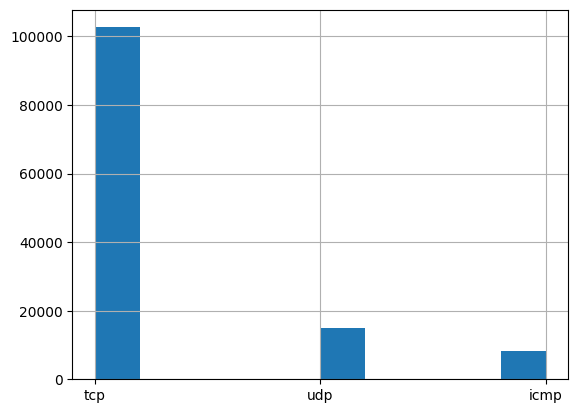

```python
%matplotlib inline
import matplotlib as plt
df["protocol_type"].hist()
```

[output not shown]

125973 rows × 42 columns

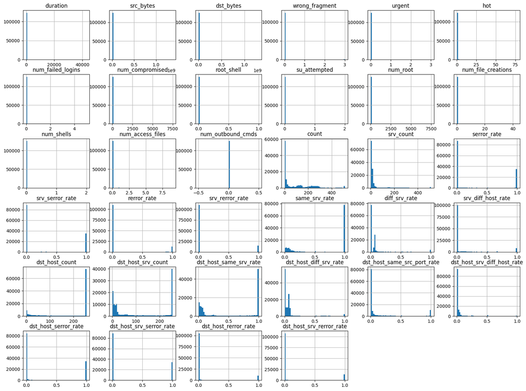

```python
df.hist(bins = 50, figsize=(20,15))
df
```

## 3.- Funciones de visualizacion de los datos

#### Buscando correlaciones

- Se puede calcular el coeficiente de correlacion estandar para validar la correlacion entre cada par de atributos
- El coeficiente de correlacion solo mide **correlaciones lineales** esto quiere decir que si x va hacia arriba, mediría si y va hacia arriba o hacia abajo
- **Hay que intentar buscar correlaciones sobre todo con el atributo objetivo(el qeu se desea predecir), en este caso es class**

```python
# El atributo class de nuestro conjunto de datos tiene valores categóricos
df["class"]
```

```
0          normal
1          normal
2         anomaly
3          normal
4          normal
           ...
125968    anomaly
125969     normal
125970     normal
125971    anomaly
125972     normal
Name: class, Length: 125973, dtype: object
```

```python
# Transformar los valores del atributo class de categóricos a numéricos
from sklearn.preprocessing import LabelEncoder
labelencoder = LabelEncoder()
df["class"] = labelencoder.fit_transform(df["class"])
df
```

|  | duration | protocol_type | service | flag | src_bytes | dst_bytes | land | wrong_fragment | urgent | hot | ... | dst_host_srv_count | dst_host_same_srv_rate | dst_host_diff_srv_rate | dst_host_same_src_port_rate | dst_host_srv_diff_host_rate | dst_host_serror_rate | dst_host_srv_serror_rate | dst_host_rerror_rate | dst_host_srv_rerror_rate | class |
| --- | --- | --- | --- | --- | --- | --- | --- | --- | --- | --- | --- | --- | --- | --- | --- | --- | --- | --- | --- | --- | --- |
| 0 | 0.0 | tcp | ftp_data | SF | 491.0 | 0.0 | 0 | 0.0 | 0.0 | 0.0 | ... | 25.0 | 0.17 | 0.03 | 0.17 | 0.00 | 0.00 | 0.00 | 0.05 | 0.00 | 1 |
| 1 | 0.0 | udp | other | SF | 146.0 | 0.0 | 0 | 0.0 | 0.0 | 0.0 | ... | 1.0 | 0.00 | 0.60 | 0.88 | 0.00 | 0.00 | 0.00 | 0.00 | 0.00 | 1 |
| 2 | 0.0 | tcp | private | S0 | 0.0 | 0.0 | 0 | 0.0 | 0.0 | 0.0 | ... | 26.0 | 0.10 | 0.05 | 0.00 | 0.00 | 1.00 | 1.00 | 0.00 | 0.00 | 0 |
| 3 | 0.0 | tcp | http | SF | 232.0 | 8153.0 | 0 | 0.0 | 0.0 | 0.0 | ... | 255.0 | 1.00 | 0.00 | 0.03 | 0.04 | 0.03 | 0.01 | 0.00 | 0.01 | 1 |
| 4 | 0.0 | tcp | http | SF | 199.0 | 420.0 | 0 | 0.0 | 0.0 | 0.0 | ... | 255.0 | 1.00 | 0.00 | 0.00 | 0.00 | 0.00 | 0.00 | 0.00 | 0.00 | 1 |
| ... | ... | ... | ... | ... | ... | ... | ... | ... | ... | ... | ... | ... | ... | ... | ... | ... | ... | ... | ... | ... | ... |
| 125968 | 0.0 | tcp | private | S0 | 0.0 | 0.0 | 0 | 0.0 | 0.0 | 0.0 | ... | 25.0 | 0.10 | 0.06 | 0.00 | 0.00 | 1.00 | 1.00 | 0.00 | 0.00 | 0 |
| 125969 | 8.0 | udp | private | SF | 105.0 | 145.0 | 0 | 0.0 | 0.0 | 0.0 | ... | 244.0 | 0.96 | 0.01 | 0.01 | 0.00 | 0.00 | 0.00 | 0.00 | 0.00 | 1 |
| 125970 | 0.0 | tcp | smtp | SF | 2231.0 | 384.0 | 0 | 0.0 | 0.0 | 0.0 | ... | 30.0 | 0.12 | 0.06 | 0.00 | 0.00 | 0.72 | 0.00 | 0.01 | 0.00 | 1 |
| 125971 | 0.0 | tcp | klogin | S0 | 0.0 | 0.0 | 0 | 0.0 | 0.0 | 0.0 | ... | 8.0 | 0.03 | 0.05 | 0.00 | 0.00 | 1.00 | 1.00 | 0.00 | 0.00 | 0 |
| 125972 | 0.0 | tcp | ftp_data | SF | 151.0 | 0.0 | 0 | 0.0 | 0.0 | 0.0 | ... | 77.0 | 0.30 | 0.03 | 0.30 | 0.00 | 0.00 | 0.00 | 0.00 | 0.00 | 1 |

125973 rows × 42 columns

```python
# Mostrar la correlacion entre los atributos del DataSet
corr_matrix = df.corr(numeric_only = True)
corr_matrix["class"].sort_values(ascending = False)
```

```
class                          1.000000
same_srv_rate                  0.751913
dst_host_srv_count             0.722535
dst_host_same_srv_rate         0.693803
srv_diff_host_rate             0.119377
num_access_files               0.036701
su_attempted                   0.022448
num_file_creations             0.021271
root_shell                     0.020285
hot                            0.013083
num_root                       0.011452
num_compromised                0.010198
num_shells                     0.009472
num_failed_logins              0.003755
urgent                         0.002787
srv_count                     -0.000771
dst_bytes                     -0.004118
src_bytes                     -0.005921
duration                      -0.048785
dst_host_srv_diff_host_rate   -0.062332
dst_host_same_src_port_rate   -0.092444
wrong_fragment                -0.095905
diff_srv_rate                 -0.203660
dst_host_diff_srv_rate        -0.242898
dst_host_rerror_rate          -0.252563
rerror_rate                   -0.253397
dst_host_srv_rerror_rate      -0.253430
srv_rerror_rate               -0.253504
dst_host_count                -0.375052
count                         -0.576444
srv_serror_rate               -0.648289
serror_rate                   -0.650652
dst_host_serror_rate          -0.651842
dst_host_srv_serror_rate      -0.654985
num_outbound_cmds                   NaN
Name: class, dtype: float64
```

```python
# Mostrar correlacion lineal entre todos los atributos del DataSet
df.corr(numeric_only = True)
```

|  | duration | src_bytes | dst_bytes | wrong_fragment | urgent | hot | num_failed_logins | num_compromised | root_shell | su_attempted | ... | dst_host_srv_count | dst_host_same_srv_rate | dst_host_diff_srv_rate | dst_host_same_src_port_rate | dst_host_srv_diff_host_rate | dst_host_serror_rate | dst_host_srv_serror_rate | dst_host_rerror_rate | dst_host_srv_rerror_rate | class |
| --- | --- | --- | --- | --- | --- | --- | --- | --- | --- | --- | --- | --- | --- | --- | --- | --- | --- | --- | --- | --- | --- |
| duration | 1.000000 | 0.070737 | 0.034878 | -0.009866 | 0.003830 | 0.000705 | 0.009528 | 0.042679 | 0.052791 | 0.087183 | ... | -0.109776 | -0.116005 | 0.254195 | 0.228737 | -0.026669 | -0.064948 | -0.064361 | 0.173815 | 0.199024 | -0.048785 |
| src_bytes | 0.070737 | 1.000000 | 0.000204 | -0.000693 | -0.000059 | 0.000295 | -0.000208 | -0.000086 | -0.000272 | -0.000186 | ... | -0.006861 | -0.006572 | 0.000900 | 0.000431 | -0.001655 | -0.004503 | -0.003397 | -0.001468 | 0.012449 | -0.005921 |
| dst_bytes | 0.034878 | 0.000204 | 1.000000 | -0.000440 | 0.000248 | -0.000344 | 0.000504 | 0.001233 | 0.001069 | 0.001133 | ... | -0.004224 | -0.004424 | 0.011031 | 0.011747 | -0.001281 | -0.003024 | -0.002944 | 0.011729 | 0.011223 | -0.004118 |
| wrong_fragment | -0.009866 | -0.000693 | -0.000440 | 1.000000 | -0.000692 | -0.008508 | -0.002418 | -0.001044 | -0.003280 | -0.002187 | ... | -0.045240 | -0.048733 | 0.059797 | 0.037177 | -0.016252 | -0.051917 | -0.055917 | 0.028890 | -0.033682 | -0.095905 |
| urgent | 0.003830 | -0.000059 | 0.000248 | -0.000692 | 1.000000 | 0.000293 | 0.097507 | 0.033329 | 0.075199 | 0.097710 | ... | -0.007897 | -0.004489 | 0.006840 | 0.002741 | 0.005176 | -0.004749 | -0.004834 | -0.002999 | -0.002912 | 0.002787 |
| hot | 0.000705 | 0.000295 | -0.000344 | -0.008508 | 0.000293 | 1.000000 | 0.003715 | 0.002014 | 0.015379 | 0.000130 | ... | -0.051864 | -0.036293 | -0.012293 | -0.034536 | -0.024715 | -0.058222 | -0.058214 | -0.030555 | -0.031670 | 0.013083 |
| num_failed_logins | 0.009528 | -0.000208 | 0.000504 | -0.002418 | 0.097507 | 0.003715 | 1.000000 | 0.019085 | 0.032567 | 0.073175 | ... | -0.023053 | -0.001576 | -0.001945 | -0.005526 | 0.003302 | -0.011648 | -0.012299 | 0.018660 | 0.017359 | 0.003755 |
| num_compromised | 0.042679 | -0.000086 | 0.001233 | -0.001044 | 0.033329 | 0.002014 | 0.019085 | 1.000000 | 0.224872 | 0.362702 | ... | -0.010321 | -0.004995 | 0.002981 | -0.002045 | 0.004252 | -0.004377 | -0.004898 | -0.003647 | -0.003219 | 0.010198 |
| root_shell | 0.052791 | -0.000272 | 0.001069 | -0.003280 | 0.075199 | 0.015379 | 0.032567 | 0.224872 | 1.000000 | 0.609083 | ... | -0.006491 | 0.007608 | -0.005141 | 0.001568 | 0.013391 | -0.017408 | -0.015744 | -0.009107 | -0.009742 | 0.020285 |
| su_attempted | 0.087183 | -0.000186 | 0.001133 | -0.002187 | 0.097710 | 0.000130 | 0.073175 | 0.362702 | 0.609083 | 1.000000 | ... | -0.021037 | -0.015606 | 0.003834 | -0.005982 | 0.009475 | -0.005731 | -0.004161 | -0.004873 | -0.005241 | 0.022448 |
| num_root | 0.045519 | -0.000093 | 0.001229 | -0.001108 | 0.032470 | 0.001510 | 0.018112 | 0.998833 | 0.243349 | 0.391038 | ... | -0.011126 | -0.005918 | 0.003342 | -0.001646 | 0.004496 | -0.004803 | -0.005282 | -0.003827 | -0.003497 | 0.011452 |
| num_file_creations | 0.099116 | -0.000179 | 0.000089 | -0.002343 | 0.024918 | 0.028716 | 0.021774 | 0.015976 | 0.064919 | 0.044407 | ... | -0.019311 | -0.017325 | 0.006184 | -0.006837 | 0.000974 | 0.003405 | -0.000247 | -0.005235 | -0.004176 | 0.021271 |
| num_shells | -0.001593 | -0.000134 | -0.000083 | -0.001665 | -0.000144 | 0.004723 | -0.000503 | 0.001338 | 0.116648 | 0.007471 | ... | -0.011903 | -0.006134 | -0.003170 | 0.013162 | -0.001978 | -0.010896 | -0.009115 | -0.004552 | -0.006780 | 0.009472 |
| num_access_files | 0.070420 | -0.000309 | 0.000339 | -0.003689 | 0.010803 | -0.001987 | 0.000652 | 0.299631 | 0.365152 | 0.565131 | ... | 0.002383 | 0.006925 | 0.000489 | -0.011847 | 0.000048 | -0.017951 | -0.019737 | -0.013227 | -0.012854 | 0.036701 |
| num_outbound_cmds | NaN | NaN | NaN | NaN | NaN | NaN | NaN | NaN | NaN | NaN | ... | NaN | NaN | NaN | NaN | NaN | NaN | NaN | NaN | NaN | NaN |
| count | -0.079042 | -0.005152 | -0.003543 | -0.020819 | -0.005615 | -0.068697 | -0.019544 | -0.008434 | -0.025630 | -0.017729 | ... | -0.395971 | -0.473957 | 0.167454 | -0.138230 | -0.205593 | 0.459047 | 0.460809 | 0.178325 | 0.167708 | -0.576444 |
| srv_count | -0.039470 | -0.002792 | -0.001754 | 0.024457 | -0.002848 | -0.034575 | -0.009880 | -0.004279 | -0.011892 | -0.008990 | ... | 0.202248 | 0.181116 | -0.106364 | 0.158539 | -0.059141 | -0.145825 | -0.145080 | -0.101149 | -0.112767 | -0.000771 |
| serror_rate | -0.069873 | -0.003228 | -0.003059 | -0.043316 | -0.004929 | -0.059083 | -0.015254 | -0.005297 | -0.018220 | -0.007302 | ... | -0.557803 | -0.622797 | -0.018193 | -0.275975 | -0.172853 | 0.979373 | 0.981139 | -0.231810 | -0.226620 | -0.650652 |
| srv_serror_rate | -0.069510 | -0.003438 | -0.003038 | -0.056549 | -0.004889 | -0.058713 | -0.015899 | -0.005278 | -0.017796 | -0.006790 | ... | -0.555032 | -0.619130 | -0.028693 | -0.275071 | -0.171081 | 0.977596 | 0.986252 | -0.235065 | -0.233142 | -0.648289 |
| rerror_rate | 0.200682 | 0.013782 | 0.011176 | -0.033052 | -0.002896 | -0.032382 | 0.022193 | -0.003682 | -0.008983 | -0.005856 | ... | -0.251075 | -0.257613 | 0.376003 | 0.032678 | 0.034087 | -0.226257 | -0.224985 | 0.926749 | 0.964449 | -0.253397 |
| srv_rerror_rate | 0.199961 | 0.013975 | 0.011052 | -0.033507 | -0.002897 | -0.031436 | 0.021870 | -0.003642 | -0.009368 | -0.006434 | ... | -0.249500 | -0.255565 | 0.380098 | 0.029802 | 0.030974 | -0.226470 | -0.230751 | 0.917822 | 0.970208 | -0.253504 |
| same_srv_rate | 0.074681 | 0.003899 | 0.003788 | 0.054759 | 0.005967 | 0.069365 | 0.019477 | 0.008944 | 0.027652 | 0.018448 | ... | 0.705410 | 0.788978 | -0.166488 | 0.279723 | 0.216263 | -0.760648 | -0.765322 | -0.214715 | -0.214091 | 0.751913 |
| diff_srv_rate | -0.013738 | -0.000432 | -0.001703 | -0.026638 | -0.002705 | -0.016212 | -0.004438 | -0.004035 | -0.009810 | -0.006595 | ... | -0.300443 | -0.330735 | 0.496590 | -0.010664 | -0.085588 | 0.050399 | 0.047319 | 0.225388 | 0.278103 | -0.203660 |
| srv_diff_host_rate | -0.040158 | -0.002608 | -0.001674 | -0.026247 | -0.002898 | -0.026781 | -0.010122 | -0.004227 | -0.012126 | -0.009153 | ... | 0.153048 | 0.291418 | -0.118726 | 0.248366 | 0.379677 | -0.226715 | -0.227027 | -0.076798 | -0.081425 | 0.119377 |
| dst_host_count | 0.050570 | -0.005791 | 0.002528 | 0.041056 | -0.006941 | -0.012249 | -0.025476 | -0.010928 | -0.029885 | -0.013014 | ... | -0.303207 | -0.518145 | 0.144370 | -0.313014 | -0.455871 | 0.410922 | 0.407532 | 0.071924 | 0.067143 | -0.375052 |
| dst_host_srv_count | -0.109776 | -0.006861 | -0.004224 | -0.045240 | -0.007897 | -0.051864 | -0.023053 | -0.010321 | -0.006491 | -0.021037 | ... | 1.000000 | 0.896663 | -0.390314 | -0.068628 | -0.004670 | -0.572596 | -0.567594 | -0.250307 | -0.252848 | 0.722535 |
| dst_host_same_srv_rate | -0.116005 | -0.006572 | -0.004424 | -0.048733 | -0.004489 | -0.036293 | -0.001576 | -0.004995 | 0.007608 | -0.015606 | ... | 0.896663 | 1.000000 | -0.419341 | 0.135946 | 0.199187 | -0.639205 | -0.632048 | -0.257178 | -0.258147 | 0.693803 |
| dst_host_diff_srv_rate | 0.254195 | 0.000900 | 0.011031 | 0.059797 | 0.006840 | -0.012293 | -0.001945 | 0.002981 | -0.005141 | 0.003834 | ... | -0.390314 | -0.419341 | 1.000000 | 0.232567 | 0.016674 | -0.017734 | -0.026101 | 0.409123 | 0.385091 | -0.242898 |
| dst_host_same_src_port_rate | 0.228737 | 0.000431 | 0.011747 | 0.037177 | 0.002741 | -0.034536 | -0.005526 | -0.002045 | 0.001568 | -0.005982 | ... | -0.068628 | 0.135946 | 0.232567 | 1.000000 | 0.405217 | -0.278910 | -0.276497 | 0.038094 | 0.027768 | -0.092444 |
| dst_host_srv_diff_host_rate | -0.026669 | -0.001655 | -0.001281 | -0.016252 | 0.005176 | -0.024715 | 0.003302 | 0.004252 | 0.013391 | 0.009475 | ... | -0.004670 | 0.199187 | 0.016674 | 0.405217 | 1.000000 | -0.174762 | -0.173301 | 0.039792 | 0.040352 | -0.062332 |
| dst_host_serror_rate | -0.064948 | -0.004503 | -0.003024 | -0.051917 | -0.004749 | -0.058222 | -0.011648 | -0.004377 | -0.017408 | -0.005731 | ... | -0.572596 | -0.639205 | -0.017734 | -0.278910 | -0.174762 | 1.000000 | 0.985052 | -0.235535 | -0.227914 | -0.651842 |
| dst_host_srv_serror_rate | -0.064361 | -0.003397 | -0.002944 | -0.055917 | -0.004834 | -0.058214 | -0.012299 | -0.004898 | -0.015744 | -0.004161 | ... | -0.567594 | -0.632048 | -0.026101 | -0.276497 | -0.173301 | 0.985052 | 1.000000 | -0.234508 | -0.232917 | -0.654985 |
| dst_host_rerror_rate | 0.173815 | -0.001468 | 0.011729 | 0.028890 | -0.002999 | -0.030555 | 0.018660 | -0.003647 | -0.009107 | -0.004873 | ... | -0.250307 | -0.257178 | 0.409123 | 0.038094 | 0.039792 | -0.235535 | -0.234508 | 1.000000 | 0.924688 | -0.252563 |
| dst_host_srv_rerror_rate | 0.199024 | 0.012449 | 0.011223 | -0.033682 | -0.002912 | -0.031670 | 0.017359 | -0.003219 | -0.009742 | -0.005241 | ... | -0.252848 | -0.258147 | 0.385091 | 0.027768 | 0.040352 | -0.227914 | -0.232917 | 0.924688 | 1.000000 | -0.253430 |
| class | -0.048785 | -0.005921 | -0.004118 | -0.095905 | 0.002787 | 0.013083 | 0.003755 | 0.010198 | 0.020285 | 0.022448 | ... | 0.722535 | 0.693803 | -0.242898 | -0.092444 | -0.062332 | -0.651842 | -0.654985 | -0.252563 | -0.253430 | 1.000000 |

35 rows × 35 columns

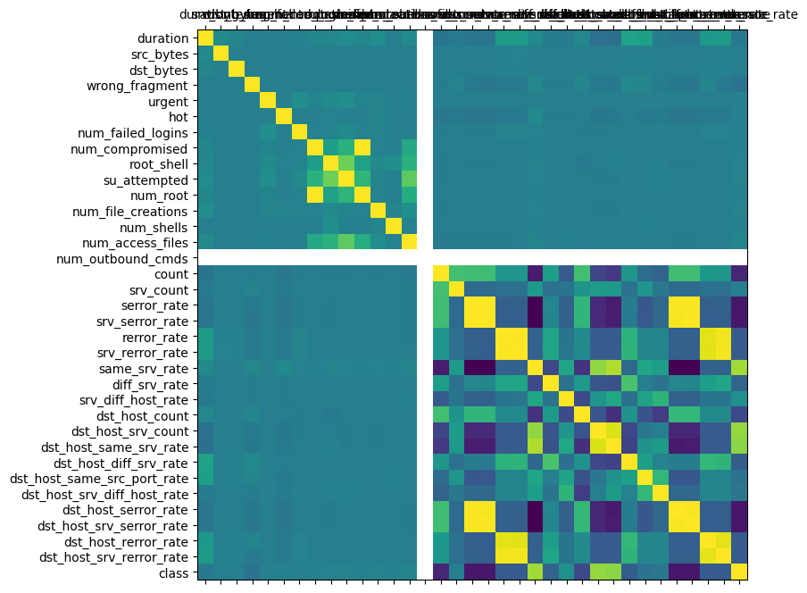

```python
# Representar graficamente la matriz de correlacion
%matplotlib inline
import matplotlib.pyplot as plt
corr = df.corr(numeric_only = True)
fig, ax = plt.subplots(figsize =(8,8))
ax.matshow(corr)
plt.xticks(range(len(corr.columns)), corr.columns);
plt.yticks(range(len(corr.columns)), corr.columns);
```

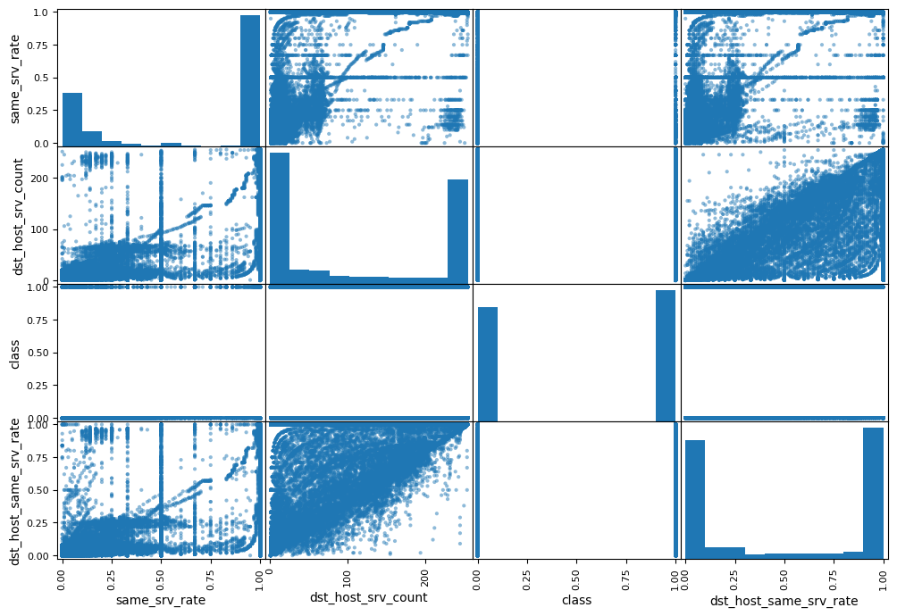

```python
# Representar graficamente las correlaciones
from pandas.plotting import scatter_matrix
attributes = ["same_srv_rate", "dst_host_srv_count", "class", "dst_host_same_srv_rate"]

scatter_matrix(df[attributes], figsize=(12,8))
plt.show()
```